# Check lapses

Sarah, Megan

2020-09-10

### Description

The goal of this file is to examine lapses reported by participants, identify cases that require individual review by Sarah and Megan, make appropriate changes to errors in lapses reported in EMA, incorporate lapses reported outside of EMA (e.g. study visits), and examine trends in lapse frequency, distance, and trustworthiness. The output of this file will be ds_lapses.rds, which will contain all lapses, reported in all settings, for all subjects.

### Setup

```r
# Packages
library(tidyverse)
library(knitr)
library(janitor)
library(lutz)
library(furrr)
library(lubridate)
library(kableExtra)
library(psych)


# Paths
path_shared_data <- "Q:/StudyData/RISK/analysis/shared/data"
path_out <- "Q:/StudyData/RISK/analysis/shared/scripts_chk/chk_lapses"
path_raw <- "Q:/StudyData/RISK/raw_data"
path_qualtrics <- "Q:/StudyData/RISK/raw_data/qualtrics"
```

### Data logs

Due to the importance of our lapse labels, we consider many data sources to determine how trustworthy participant lapse reports are. The sources that we consider are: staff data logs (explaining participant corrections, technological issues), gps data, surrounding EMA reports, daily audio check ins, and participant reported vacation periods.

We have two types of data logs to inform lapse checking:

**1) Log_ema:** This is the main file containing all corrections to all EMA variables (e.g. lapse reports, survey UTCs, subid typos). There are two types of entries: changes (detailing corrections to be made to the raw ema files) and notes (containing notes about ema reports that did not result in changes to the raw ema file, but may still be useful for context). EMA reports end up in this file if 1) there was an explicit note in the data log referecing the EMA report or 2) lapse reports were identified as suspicious/problematic by this check script and were added to the log for staff review. This script will generate a running report of these cases (log_lapses_empty) to provide a reproducible record of which cases were selected to add to log_ema.

**2) Log_add_lapses:** This file documents lapses that were reported to staff from participants during follow up visits that are not associated with an EMA report.

We will use both logs throughout this script to correct the ema files sequentially (because problems with some cases could not be identified until previous corrections were made, e.g. if a lapse date was formatted incorrectly, we cannot determine if the lapse length is negative until the date is corrected). If #JOHN determines this is not necessary to demonstrate, all corrections to the ema can be read from the log file in one command.

```r
## Open completed log files

# Log_ema
log_ema <-
  read_csv(file.path(path_out,"log_ema.csv"),
           col_types = cols(.default=col_character()))


# Log_add_lapses
log_add_lapses <-
  read_csv(file.path(path_out, "log_add_lapses.csv"),
           col_types = cols(.default = col_character(),
                            lapse = col_double(),
                            lapse_start_hour= col_double(),
                            lapse_end_hour = col_double()
                            ))

# Create empty log file
empty_log <- tibble() %>%
  mutate(response_id = "", subid = "", log_reason="",
         start_date = "", start_date_local = "", end_date = "",
         end_date_local="", lapse_start_date = "",
         lapse_start_hour = "", lapse_end_date = "",
         lapse_end_hour = "", tz = "", lapse_length="", ema_type = ""
         )
```

### Raw EMA files

Now we will load the raw EMA morning and later qualtrics files.

NOTE: raw qualtrics file times are recorded in UTC 00:00 - Abidjan, Accra…Reykjavik. These DO correct for British Summer time and are accurate relative to as_datetime conversions to UTC (UTC 00:00 London was NOT)

```r
# Open EMA morning
ema_morning<- read_csv(file.path(path_qualtrics, "ema_morning.csv")) %>%
  glimpse()
```

```
## Rows: 11,511
## Columns: 33
## $ ResponseID            <chr> "R_1HkvSG8QkPx8Eu8", "R_2uBUNUJQQ1vkJwa", "R_...
## $ ResponseSet           <chr> "Default Response Set", "Default Response Set...
## $ IPAddress             <chr> "174.197.3.173", "174.197.5.167", "174.198.15...
## $ StartDate             <dttm> 2017-03-02 15:17:11, 2017-03-03 12:31:39, 20...
## $ EndDate               <dttm> 2017-03-02 15:20:19, 2017-03-03 12:35:33, 20...
## $ RecipientLastName     <lgl> NA, NA, NA, NA, NA, NA, NA, NA, NA, NA, NA, N...
## $ RecipientFirstName    <lgl> NA, NA, NA, NA, NA, NA, NA, NA, NA, NA, NA, N...
## $ RecipientEmail        <lgl> NA, NA, NA, NA, NA, NA, NA, NA, NA, NA, NA, N...
## $ ExternalDataReference <lgl> NA, NA, NA, NA, NA, NA, NA, NA, NA, NA, NA, N...
## $ Finished              <dbl> 1, 1, 1, 1, 1, 1, 1, 1, 1, 1, 1, 1, 1, 1, 1, ...
## $ Status                <dbl> 0, 0, 0, 0, 0, 0, 0, 0, 0, 0, 0, 0, 0, 0, 0, ...
## $ SubID                 <chr> "001", "001", "001", "001", "001", "001", "00...
## $ UTC                   <dbl> NA, 1488544299, 1488717171, 1488803446, 14888...
```

[output cut: 20 more lines]

```r
# Open EMA later
ema_later <- read_csv(file.path(path_qualtrics, "ema_later.csv")) %>%
  glimpse()
```

```
## Rows: 34,316
## Columns: 30
## $ ResponseID            <chr> "R_DCzfrTzvmKyStd7", "R_2dsYfdSOBQqnVZa", "R_...
## $ ResponseSet           <chr> "Default Response Set", "Default Response Set...
## $ IPAddress             <chr> "174.197.3.173", "174.198.8.191", "174.197.5....
## $ StartDate             <dttm> 2017-03-02 20:27:53, 2017-03-03 03:00:38, 20...
## $ EndDate               <dttm> 2017-03-02 20:37:43, 2017-03-03 03:02:47, 20...
## $ RecipientLastName     <lgl> NA, NA, NA, NA, NA, NA, NA, NA, NA, NA, NA, N...
## $ RecipientFirstName    <lgl> NA, NA, NA, NA, NA, NA, NA, NA, NA, NA, NA, N...
## $ RecipientEmail        <lgl> NA, NA, NA, NA, NA, NA, NA, NA, NA, NA, NA, N...
## $ ExternalDataReference <lgl> NA, NA, NA, NA, NA, NA, NA, NA, NA, NA, NA, N...
## $ Finished              <dbl> 1, 1, 1, 1, 1, 1, 1, 1, 1, 1, 1, 1, 1, 1, 1, ...
## $ Status                <dbl> 0, 0, 0, 0, 0, 0, 0, 0, 0, 0, 0, 0, 0, 0, 0, ...
## $ SubID                 <chr> "001", "001", "001", "001", "001", "001", "00...
## $ UTC                   <dbl> 1488486473, 1488510038, 1488550270, 148863162...
```

[output cut: 17 more lines]

Now we update the raw ema logs. By using the log reason “all” we can make all corrections at this step. Since this script is walking through how all changes are selected, I will only make the first level of changes at this step (corrections from the data log)

I will also create a variable for lapse timezone that will be needed for all analyses with lapses going forward. We start by assigning all lapses to “America/Chicago” and the log corrects lapses that are in different timezones

```r
## Update raw ema file using the data log

#create timezone variable for lapses

ema_morning <- ema_morning %>%
  mutate(EMAM_1.6 = "America/Chicago")

ema_morning <- ema_morning %>%
  mutate(EMAL_1.6 = "America/Chicago")



# Update ema morning
ema_morning <- update_from_log(ema_morning, "Data log entry")

# Update ema later
ema_later <- update_from_log(ema_later, "Data log entry")
```

For the rest of this script, I will be working with a lapses file (the combined ema files filtered down to lapses only). I rename the varibles so they are easier to work with, but changes will still be made to raw ema files with the original names.

Note: the ema utc variable corresponds to the utc of the survey start_date. It is included because the staff data log often identifies cases by sub_id + utc.

```r
#Combining EMA files

#Clean up morning ema
ema_morning <- ema_morning %>%
  clean_names(case="snake") %>%
  select(c(response_id, sub_id, utc, start_date, end_date, emam_1,
           emam_1_1, emam_1_2, emam_1_3, emam_1_4, emam_1_5,
           finished)) %>%
  mutate(ema_type = "morning") %>%
  rename(lapse = emam_1,
         lapse_start_date = emam_1_1,
         lapse_start_hour = emam_1_2,
         lapse_end_date = emam_1_3,
         lapse_end_hour = emam_1_4,
         abstinent = emam_1_5,
         subid = sub_id)

#Clean up later ema
ema_later<- ema_later %>%
  clean_names(case="snake") %>%
  select(c(response_id, utc, sub_id, start_date, end_date, emal_1,
           emal_1_1, emal_1_2, emal_1_3, emal_1_4, emal_1_5,
           finished)) %>%
  mutate(ema_type = "later") %>%
  rename(lapse = emal_1,
         lapse_start_date = emal_1_1,
         lapse_start_hour = emal_1_2,
         lapse_end_date = emal_1_3,
         lapse_end_hour = emal_1_4,
         abstinent = emal_1_5,
         subid = sub_id)

#Create one ema tibble
ema <- full_join(ema_morning, ema_later, copy = TRUE)

#Note: The survey start and end dates are in UTC
#Since GPS does everything in CST, we will too
ema <- ema %>%
  mutate(start_date = as_datetime(
    start_date, tz = "America/Chicago"),
    end_date = as_datetime(
    end_date, tz = "America/Chicago"))

#Some descriptives
ema_sub <- ema %>%
  mutate(sur_time = as.numeric(end_date - start_date),
         start_date_d = as_date(start_date)) %>%
  group_by(subid) %>%
  summarise(n = n(), days = length(unique(start_date_d)),sur_time = mean(sur_time))

nmorn <- ema %>%
  filter(ema_type=="morning") %>%
  group_by(subid) %>%
  summarise(n = n())

nlat <- ema %>%
  filter(ema_type=="later") %>%
  group_by(subid) %>%
  summarise(n = n())
```

A total of **45827** EMAs (**11511** morning and **34316** later EMA reports) were submitted by **173** participants. **735** of these surveys are unfinished.

On average, each subject completed **265** EMA surveys (**67** morning and **200** later surveys) across **74.9710983** days. The highest number of surveys completed by a participant was **602** and the lowest was **1**. Surveys took an average of **119** seconds to complete. *(We will do more in depth descriptives of ema data once lapses are cleaned)*

### Make lapses file

```r
#Create lapses file
#We will only look at participants who completed the study
completed_subs <- list.files(path = path_raw) %>%
  str_extract("\\d+") %>%
  keep(!is.na(.))

lapses <-  ema %>%
  filter(lapse==2) %>%
  filter(subid %in% completed_subs) %>%
  arrange(subid)

lapses_sub <- lapses %>%
  group_by(subid) %>%
  summarise(n=n())

glimpse(lapses)
```

```
## Rows: 1,410
## Columns: 13
## $ response_id      <chr> "R_3LhCeP0CY3rOJQu", "R_233PcDxIPdh1rpF", "R_3oTRL...
## $ subid            <chr> "001", "001", "002", "002", "002", "002", "002", "...
## $ utc              <dbl> 1489773234, 1491177658, 1491307485, 1493562787, 14...
## $ start_date       <dttm> 2017-03-17 12:53:54, 2017-04-02 18:00:58, 2017-04...
## $ end_date         <dttm> 2017-03-17 12:54:41, 2017-04-02 18:01:07, 2017-04...
## $ lapse            <dbl> 2, 2, 2, 2, 2, 2, 2, 2, 2, 2, 2, 2, 2, 2, 2, 2, 2,...
## $ lapse_start_date <chr> NA, NA, "04-03-2017", "04-29-2017", "05-06-2017", ...
## $ lapse_start_hour <dbl> NA, NA, 18, 20, 20, 19, 11, 22, 21, 20, 21, 21, 20...
## $ lapse_end_date   <chr> NA, NA, "04-03-2017", "04-29-2017", "05-06-2017", ...
## $ lapse_end_hour   <dbl> NA, NA, 21, 22, 21, 19, 11, 22, 21, 21, 21, 21, 21...
## $ abstinent        <dbl> NA, NA, 3, 3, 3, 3, 3, 3, 3, 3, 3, 3, 3, 3, 3, 3, ...
## $ finished         <dbl> 0, 0, 1, 1, 1, 1, 1, 1, 1, 1, 1, 1, 1, 1, 1, 1, 1,...
## $ ema_type         <chr> "later", "later", "morning", "morning", "morning",...
```

### Unfinished lapse reports

Previous EMA cleaning removed all unfinished surveys unless the data cleaning log indicated a lapse on an incomplete EMA report was valid. To be more inclusive, we will retain all lapses from incomplete reports if we have lapse date data.

First, we identify incomplete surveys that do not provide any lapse date data.

```r
#Reports missing lapse date or time
incomplete_lapses <- lapses %>%
  filter(is.na(lapse_start_date)|
         is.na(lapse_start_hour)|
         is.na(lapse_end_date)|
         is.na(lapse_end_hour)
  ) %>%
  select(c(response_id, subid,lapse_start_date,
           lapse_start_hour, lapse_end_date,
           lapse_end_hour, finished, everything())
  )

glimpse(incomplete_lapses)
```

```
## Rows: 75
## Columns: 13
## $ response_id      <chr> "R_3LhCeP0CY3rOJQu", "R_233PcDxIPdh1rpF", "R_2EiMq...
## $ subid            <chr> "001", "001", "007", "009", "011", "019", "032", "...
## $ lapse_start_date <chr> NA, NA, NA, NA, NA, NA, NA, NA, NA, NA, NA, NA, NA...
## $ lapse_start_hour <dbl> NA, NA, NA, NA, NA, NA, NA, NA, NA, NA, NA, NA, NA...
## $ lapse_end_date   <chr> NA, NA, NA, NA, NA, NA, NA, NA, NA, NA, NA, NA, NA...
## $ lapse_end_hour   <dbl> NA, NA, NA, NA, NA, NA, NA, NA, NA, NA, NA, NA, NA...
## $ finished         <dbl> 0, 0, 0, 0, 0, 0, 0, 0, 0, 0, 0, 0, 0, 0, 0, 0, 0,...
## $ utc              <dbl> 1489773234, 1491177658, 1503632174, 1506781641, 15...
## $ start_date       <dttm> 2017-03-17 12:53:54, 2017-04-02 18:00:58, 2017-08...
## $ end_date         <dttm> 2017-03-17 12:54:41, 2017-04-02 18:01:07, 2017-08...
## $ lapse            <dbl> 2, 2, 2, 2, 2, 2, 2, 2, 2, 2, 2, 2, 2, 2, 2, 2, 2,...
## $ abstinent        <dbl> NA, NA, NA, NA, NA, NA, NA, NA, NA, NA, NA, NA, NA...
## $ ema_type         <chr> "later", "later", "later", "morning", "later", "la...
```

There are **75** lapse reports missing all lapse time labels across **42** participants. These are all unfinished surveys. Since they do not contain any lapse date information, we will remove them

```r
#Remove incomplete lapse reports
lapses <-
  lapses %>%
  filter(!response_id %in% incomplete_lapses$response_id)

#Confirm no more missing lapse reports
lapses %>%
  filter(is.na(lapse_start_date)|
         is.na(lapse_start_hour)|
         is.na(lapse_end_date)|
         is.na(lapse_end_hour)
  ) %>% glimpse()
```

```
## Rows: 0
## Columns: 13
## $ response_id      <chr>
## $ subid            <chr>
## $ utc              <dbl>
## $ start_date       <dttm>
## $ end_date         <dttm>
## $ lapse            <dbl>
## $ lapse_start_date <chr>
## $ lapse_start_hour <dbl>
## $ lapse_end_date   <chr>
## $ lapse_end_hour   <dbl>
## $ abstinent        <dbl>
## $ finished         <dbl>
## $ ema_type         <chr>
```

Partially finished surveys which have reported lapse dates will be reatined (unless stated not to in the data log). In general, staff checked in with individuals about unfinished surveys, to confirm if the report was valid. Incomplete lapse reports with dates that were invalid were removed by log_ema guided by data log notes from follow up interviews.

```r
lapses %>%
  filter(finished == 0) %>%
  select(contains("lapse"),
         everything()) %>%
  glimpse()
```

```
## Rows: 26
## Columns: 13
## $ lapse            <dbl> 2, 2, 2, 2, 2, 2, 2, 2, 2, 2, 2, 2, 2, 2, 2, 2, 2,...
## $ lapse_start_date <chr> "10-21-2017", "11-16-2017", "12-12-2017", "02-05-2...
## $ lapse_start_hour <dbl> 1, 11, 21, 21, 21, 13, 17, 13, 1, 18, 24, 16, 21, ...
## $ lapse_end_date   <chr> "10-21-2017", "11-16-2017", "12-12-2017", "02-05-2...
## $ lapse_end_hour   <dbl> 1, 11, 22, 23, 21, 16, 18, 13, 16, 18, 3, 17, 21, ...
## $ response_id      <chr> "R_XzxSgEbf8IUq4aB", "R_vdAqjiyTdnVQUnf", "R_pxGO3...
## $ subid            <chr> "016", "016", "016", "034", "039", "048", "048", "...
## $ utc              <dbl> 1508597249, 1510860325, 1513138361, 1517944400, 15...
## $ start_date       <dttm> 2017-10-21 08:47:29, 2017-11-16 13:25:25, 2017-12...
## $ end_date         <dttm> 2017-10-21 08:48:23, 2017-11-16 13:26:08, 2017-12...
## $ abstinent        <dbl> 1, 3, 3, 2, 3, 3, 3, 3, 3, 2, 2, 3, 3, NA, 3, 3, 3...
## $ finished         <dbl> 0, 0, 0, 0, 0, 0, 0, 0, 0, 0, 0, 0, 0, 0, 0, 0, 0,...
## $ ema_type         <chr> "morning", "later", "later", "morning", "later", "...
```

```r
#T26 partially finished surveys, all have lapse date and hours provided
```

### Lapse date formatting

Many of our lapse checking procedures will not work if dates are entered in the incorrect format. In the EMA surveys, lapse dates are entered as mm-dd-yyyy and hours are single digit integers. Participants were supposed to select these hours from a calendar/drop down list, but they were also able to manually enter responses (leading to a wide variety of responses).

Lapse hour formatting:

```r
#Identify badly formatted lapse hours

#Lapse hours should be numeric integers between 0 and 24
lapses %>%
  summarise(across(
    .cols = c(lapse_start_hour, lapse_end_hour),
    .fns = list(min, max)
    )) %>%
  kable() %>%
   kable_styling(
    bootstrap_options = "condensed",
    full_width = FALSE,
    position = "left")
```

| lapse_start_hour_1 | lapse_start_hour_2 | lapse_end_hour_1 | lapse_end_hour_2 |
| --- | --- | --- | --- |
| 1 | 24 | 1 | 24 |

Format looks good, but it looks like we enter 24 for midnight. ##JOHN: do you have a preference?

Doing a quick skim, people were kind of all over the place with whether they used the right date around 24. We will catch these when we look for negative lapses/lapses that are really long.

```r
#Glimpse of lapses with hr 24 start or end times

lapses %>%
  filter(lapse_start_hour==24 | lapse_end_hour == 24) %>%
  select(c(lapse_start_date,lapse_start_hour, lapse_end_date,
           lapse_end_hour, everything())) %>%
  glimpse()
```

```
## Rows: 100
## Columns: 13
## $ lapse_start_date <chr> "06-24-2017", "07-05-2017", "07-07-2017", "07-23-2...
## $ lapse_start_hour <dbl> 24, 22, 24, 22, 23, 24, 24, 24, 22, 20, 23, 21, 22...
## $ lapse_end_date   <chr> "06-25-2017", "07-05-2017", "07-08-2017", "07-23-2...
## $ lapse_end_hour   <dbl> 1, 24, 2, 24, 24, 1, 24, 1, 24, 24, 24, 24, 24, 24...
## $ response_id      <chr> "R_VP5LfR17hDlx5cJ", "R_21zjA5IXEQqCRwy", "R_3oRUd...
## $ subid            <chr> "007", "007", "007", "007", "010", "011", "011", "...
## $ utc              <dbl> 1498322134, 1499353334, 1499535024, 1500872867, 15...
## $ start_date       <dttm> 2017-06-24 10:35:34, 2017-07-06 09:02:14, 2017-07...
## $ end_date         <dttm> 2017-06-24 10:36:39, 2017-07-06 09:03:49, 2017-07...
## $ lapse            <dbl> 2, 2, 2, 2, 2, 2, 2, 2, 2, 2, 2, 2, 2, 2, 2, 2, 2,...
## $ abstinent        <dbl> 3, 3, 3, 3, 2, 1, 1, 3, 3, 3, 2, 3, 2, 2, 2, 2, 2,...
## $ finished         <dbl> 1, 1, 1, 1, 1, 1, 1, 1, 1, 1, 1, 1, 1, 1, 1, 1, 1,...
## $ ema_type         <chr> "morning", "morning", "morning", "later", "morning...
```

For date math to work correctly, hour 24 should be paired with the date leading up to midnight (while using 00:00 would use the new date at midnight.

Lapse date formatting:

```r
#Identify badly formatted lapse dates

bad_dates <- lapses %>%
  filter(is.na(parse_date_time(
               lapses$lapse_start_date, orders="mdy")) |
         is.na(parse_date_time(
               lapses$lapse_end_date, orders="mdy")
               ))

glimpse(bad_dates)
```

```
## Rows: 9
## Columns: 13
## $ response_id      <chr> "R_3dYBfbOYTYdLRRP", "R_2WO6xwo1ZHdqR7n", "R_6ldW7...
## $ subid            <chr> "042", "098", "104", "137", "161", "175", "191", "...
## $ utc              <dbl> 1521938445, 1536981341, 1535259939, 1541275293, 15...
## $ start_date       <dttm> 2018-03-24 19:40:44, 2018-09-14 21:15:41, 2018-08...
## $ end_date         <dttm> 2018-03-24 19:42:13, 2018-09-14 21:16:54, 2018-08...
## $ lapse            <dbl> 2, 2, 2, 2, 2, 2, 2, 2, 2
## $ lapse_start_date <chr> "03-24-20184", "09-14-2018", "08-25-2018", "2", "3...
## $ lapse_start_hour <dbl> 16, 17, 20, 16, 17, 10, 23, 15, 14
## $ lapse_end_date   <chr> "03-24-2018", "No", "07:00", "11-03-2018", "01-01-...
## $ lapse_end_hour   <dbl> 19, 17, 24, 16, 1, 10, 19, 15, 21
## $ abstinent        <dbl> 3, 3, 3, 2, 3, 3, 3, 3, 3
## $ finished         <dbl> 1, 1, 1, 0, 1, 1, 1, 1, 1
## $ ema_type         <chr> "later", "later", "later", "later", "later", "late...
```

There are **9** lapse dates across **7** participants that are not in month day year readable format. This is after the many corrections made in the initial data log.

```r
#Add badly formatted lapses to the empty log
empty_log <- add_to_log(bad_dates, "Bad date format")
```

Correcting badly formatting dates with the log:

```r
#Update date formatting from the complete log
lapses <- update_from_log(lapses, reason = "Bad date format")

#Check that dates were corrected
lapses %>%
  filter(response_id %in% bad_dates$response_id)%>%
  select(response_id, lapse_start_date,
         lapse_start_hour, lapse_end_date,
         lapse_end_hour, everything()) %>%
  glimpse()
```

```
## Rows: 9
## Columns: 13
## $ response_id      <chr> "R_3dYBfbOYTYdLRRP", "R_2WO6xwo1ZHdqR7n", "R_6ldW7...
## $ lapse_start_date <chr> "03-24-2018", "09-14-2018", "08-25-2018", "11-03-2...
## $ lapse_start_hour <dbl> 16, 17, 20, 16, 17, 10, 19, 15, 14
## $ lapse_end_date   <chr> "03-24-2018", "09-14-2018", "08-25-2018", "11-03-2...
## $ lapse_end_hour   <dbl> 19, 17, 23, 16, 1, 10, 19, 15, 20
## $ subid            <chr> "042", "098", "104", "137", "161", "175", "191", "...
## $ utc              <dbl> 1521938445, 1536981341, 1535259939, 1541275293, 15...
## $ start_date       <dttm> 2018-03-24 19:40:44, 2018-09-14 21:15:41, 2018-08...
## $ end_date         <dttm> 2018-03-24 19:42:13, 2018-09-14 21:16:54, 2018-08...
## $ lapse            <dbl> 2, 2, 2, 2, 2, 2, 2, 2, 2
## $ abstinent        <dbl> 3, 3, 3, 2, 3, 3, 3, 3, 3
## $ finished         <dbl> 1, 1, 1, 0, 1, 1, 1, 1, 1
## $ ema_type         <chr> "later", "later", "later", "later", "later", "late...
```

```r
#All dates are now in the expected format
rm(bad_dates)
```

### Adding timezones to lapses

Lapse reports do not contain time zones and are in the local time of the participant at the moment of the lapse. Since lapses can be reported on any ema, we cannot assume that the timezone of the ema report = the timezone of the lapse.

We will use the participants closest gps point to their reported lapse time to determine the most likely timezone of the lapse.

Get timezone of each gps point:

```r
# Open aggregate gps file

gps <- read_rds(file.path(path_shared_data, "ds_gps.rds")) %>%
  ungroup() #is gps meant to be saved as a rowwise file?

# Get timezone based on lat/long coordinates (lutz package)
# Note: 'fast' method preferred, 'accurate' returns overlapping tzs
gps$lutz_tz <- tz_lookup_coords(gps$lat, gps$long)

# Select only gps vars needed for lapse context
gps <- gps %>%
  select(subid, lat, long, time_central,lutz_tz)
```

Timezones present in GPS data:

```r
# Check out all local time zones in the gps file
u_tzs <- gps %>%
  filter(!is.na(lutz_tz)) %>%
  pull(lutz_tz) %>%
  unique(.)

u_tzs
```

```
##  [1] "America/Chicago"              "America/Detroit"
##  [3] "America/Indiana/Indianapolis" "America/New_York"
##  [5] "America/Denver"               "America/Phoenix"
##  [7] "America/Los_Angeles"          "America/Kentucky/Louisville"
##  [9] "America/Indiana/Vincennes"    "America/Indiana/Tell_City"
## [11] "America/Toronto"              "Etc/GMT+9"
## [13] "Etc/GMT+10"                   "Pacific/Honolulu"
## [15] "America/Menominee"            "America/Mexico_City"
## [17] "America/Boise"
```

```r
#Getting info about non central tzs
other_tz <- gps %>%
  filter(!is.na(lutz_tz)) %>%
  filter(!lutz_tz=="America/Chicago")
```

There are **17** unique timezones in the gps file. **38** participants had a total of **56953** gps observations in timezones other than America/Chicago.

Fun fact: there are a ton of indiana ones because indiana has tons of small counties who do whatever they want with timezones and daylight savings

Use timezones to convert GPS central time to local time:

```r
#Get local gps tzs

#Instead of calculating local time for each row (1 million), we group the data by timezone to batch convert all dates for that tz

gps <- gps %>%
  filter(!is.na(lutz_tz)) %>%
  group_by(lutz_tz) %>%
  group_map(function(.x, .y){
    .x %>%
      mutate(time_local = as_datetime(time_central, tz = .y$lutz_tz)
      )%>%
      mutate(date_local = as_date(time_local),
             time_local=as.character(time_local))
  }) %>%
  reduce(full_join) %>%
  left_join(gps, .)
```

Pair nearest gps timezone with lapses:

For every lapse, we will search for the closest day with gps data and document all time zones on that date. If a lapse date has more than one time zone, we will visually inspect it to determine the most likely tz for the lapse.

```r
# Set up for parallel future_pmap
plan(multisession)

# Use pmap to iterate over every row of the lapse file
lapses <- lapses %>%
  # Select down to only variables we need to search gps
  select(subid, lapse_start_date, response_id) %>%
  future_pmap_dfr(function(...){
   gps %>%
      # filter gps data to current sub, only relevant vars
      filter(subid==..1 & !is.na(lutz_tz)) %>%
      select(subid, lutz_tz, date_local) %>%
      # calculate distance between lapse start and gps dates
      mutate(tz_distance = abs(mdy(..2) - date_local)) %>%
      # filter down to the closest gps dates
      filter(tz_distance == min(tz_distance)) %>%
      # Create variables
      mutate(response_id = ..3, #key to join back to lapses
             tz = Reduce(str_c,unique(lutz_tz)), # all lapse date tzs
             tz_num = length(unique(lutz_tz)), # num lapse date tzs
             tz_distance = as.numeric(tz_distance)) %>%
      rename(tz_date = date_local) %>% #keep closest tz date
      select(-lutz_tz) %>%
      slice(1)
  }) %>%
  left_join(lapses, .)

#close parallel backends
future:::ClusterRegistry("stop")
```

### Lapses with multiple timezones

Some participants were in multiple timezones on the day of their lapse

```r
#Identify lapses with multiple timezones

mult_tz <- lapses %>%
  filter(tz_num>1) %>%
  select(c(response_id, tz, tz_num, tz_distance, everything()))

glimpse(mult_tz)
```

```
## Rows: 18
## Columns: 17
## $ response_id      <chr> "R_vdAqjiyTdnVQUnf", "R_A1h62CSR3omtxpn", "R_SGHWz...
## $ tz               <chr> "America/Los_AngelesAmerica/PhoenixAmerica/DenverA...
## $ tz_num           <int> 4, 2, 2, 4, 2, 2, 2, 3, 3, 3, 3, 3, 2, 2, 2, 2, 2, 3
## $ tz_distance      <dbl> 0, 0, 0, 0, 1, 0, 0, 0, 0, 0, 0, 0, 0, 0, 0, 0, 0, 0
## $ subid            <chr> "016", "037", "037", "037", "043", "043", "043", "...
## $ utc              <dbl> 1510860325, 1521830593, 1521850846, 1524271450, 15...
## $ start_date       <dttm> 2017-11-16 13:25:25, 2018-03-23 13:43:12, 2018-03...
## $ end_date         <dttm> 2017-11-16 13:26:08, 2018-03-23 13:43:51, 2018-03...
## $ lapse            <dbl> 2, 2, 2, 2, 2, 2, 2, 2, 2, 2, 2, 2, 2, 2, 2, 2, 2, 2
## $ lapse_start_date <chr> "11-16-2017", "03-23-2018", "03-23-2018", "04-20-2...
## $ lapse_start_hour <dbl> 11, 12, 12, 17, 14, 19, 23, 19, 10, 18, 11, 17, 19...
## $ lapse_end_date   <chr> "11-16-2017", "03-23-2018", "03-23-2018", "04-20-2...
## $ lapse_end_hour   <dbl> 11, 14, 16, 19, 20, 21, 24, 20, 10, 19, 12, 23, 22...
## $ abstinent        <dbl> 3, 2, 2, 2, 1, 2, 2, 2, 2, 2, 2, 2, 2, 3, 3, 2, 2, 2
## $ finished         <dbl> 0, 1, 1, 1, 1, 1, 1, 1, 1, 1, 1, 1, 1, 1, 1, 1, 1, 1
## $ ema_type         <chr> "later", "later", "later", "later", "later", "late...
## $ tz_date          <date> 2017-11-16, 2018-03-23, 2018-03-23, 2018-04-20, 2...
```

There are **18** lapses that occurred on days with more than 1 tz recorded. **9** participants had lapses on days with more than one tz. The average number of tzs for these days was **2.5555556**, with the highest number of tzs on a day being **4** We will visually inspect these lapses in the log to determine the best timezone.

```r
#Add multiple tz cases to empty log

empty_log <- add_to_log(mult_tz, "Multiple timezones")
```

Correct multiple timezones with the log:

```r
#Update multiple time zones from the complete log
lapses <- update_from_log(lapses, reason = "Multiple timezones")

#Checking to make sure that worked
lapses %>%
  filter(response_id %in% mult_tz$response_id) %>%
  pull(tz)
```

```
##  [1] "America/Los_Angeles" "America/Chicago"     "America/Chicago"
##  [4] "America/New_York"    "America/New_York"    "America/New_York"
##  [7] "America/New_York"    "America/Chicago"     "America/New_York"
## [10] "America/Chicago"     "America/Chicago"     "America/New_York"
## [13] "America/Chicago"     "America/Chicago"     "America/Chicago"
## [16] "America/New_York"    "America/New_York"    "America/Detroit"
```

```r
#remove uneeded vars
rm(mult_tz)
lapses$tz_num = NULL
```

Looks good now! All lapses now have one timezone.

### Lapses with non-America/Chicago timezones

In general, these look trustworthy, but we will review any lapse not in the central tz

```r
#Examine non-America/Chicago lapses
new_tz <- lapses %>%
  filter(!is.na(tz)) %>%
  filter(!tz=="America/Chicago") %>%
  arrange(subid)

glimpse(new_tz)
```

```
## Rows: 55
## Columns: 16
## $ response_id      <chr> "R_1dA0nZ4oXuAqWBi", "R_vdAqjiyTdnVQUnf", "R_2WvRU...
## $ subid            <chr> "016", "016", "025", "025", "025", "037", "037", "...
## $ utc              <dbl> 1510715516, 1510860325, 1515122710, 1515210778, 15...
## $ start_date       <dttm> 2017-11-14 21:11:55, 2017-11-16 13:25:25, 2018-01...
## $ end_date         <dttm> 2017-11-14 21:15:57, 2017-11-16 13:26:08, 2018-01...
## $ lapse            <dbl> 2, 2, 2, 2, 2, 2, 2, 2, 2, 2, 2, 2, 2, 2, 2, 2, 2,...
## $ lapse_start_date <chr> "11-14-2017", "11-16-2017", "01-04-2018", "01-05-2...
## $ lapse_start_hour <dbl> 18, 11, 21, 21, 20, 18, 18, 18, 15, 17, 15, 18, 20...
## $ lapse_end_date   <chr> "11-14-2017", "11-16-2017", "01-04-2018", "01-05-2...
## $ lapse_end_hour   <dbl> 19, 11, 22, 23, 22, 18, 18, 21, 16, 19, 17, 20, 21...
## $ abstinent        <dbl> 3, 3, 2, 2, 2, 3, 2, 2, 2, 2, 2, 2, 2, 2, 1, 2, 2,...
## $ finished         <dbl> 1, 0, 1, 1, 1, 1, 1, 1, 1, 1, 1, 1, 1, 1, 1, 1, 1,...
## $ ema_type         <chr> "later", "later", "later", "later", "later", "late...
## $ tz_date          <date> 2017-11-14, 2017-11-16, 2018-01-04, 2018-01-05, 2...
## $ tz_distance      <dbl> 0, 0, 0, 0, 0, 0, 0, 0, 0, 0, 0, 0, 0, 0, 1, 0, 0,...
## $ tz               <chr> "America/Los_Angeles", "America/Los_Angeles", "Ame...
```

There are **5** unique timezones across our lapse reports. **55** lapses across **12** participants were in timezones other than America/Chicago.

```r
#Add new tz cases to log
empty_log <- add_to_log(new_tz, "New timezone")
```

All new timezones in the log were confirmed - no updates needed to this file (except to be sure to include tz in lapse files).

Now that we know the tz of the lapses, we will convert the survey times to local time (for calculation of lapse distance, interpreting data,etc)

```r
#Create local survey start and end times. Group by tz to convert in batches.
#Be sure to save as character when you have multiple tzones in 1 variable.
lapses <- lapses %>%
  group_by(tz) %>%
  group_map(function(.x, .y, ...){
    .x %>%
      mutate(start_date_local = as.character(
        with_tz(start_date, tz = .y$tz)),
             end_date_local = as.character(
               with_tz(end_date, tz = .y$tz)))
        }) %>%
  reduce(full_join) %>%
  left_join(lapses, .)


#Check that it worked - The only lapses where start date does not equal the local start date  should be lapses in different tzs.
lapses %>%
  filter(as.character(start_date) != start_date_local) %>%
  select(response_id, start_date, start_date_local, end_date, end_date_local, tz, everything()) %>%
glimpse()
```

```
## Rows: 55
## Columns: 18
## $ response_id      <chr> "R_1dA0nZ4oXuAqWBi", "R_vdAqjiyTdnVQUnf", "R_2WvRU...
## $ start_date       <dttm> 2017-11-14 21:11:55, 2017-11-16 13:25:25, 2018-01...
## $ start_date_local <chr> "2017-11-14 19:11:55", "2017-11-16 11:25:25", "201...
## $ end_date         <dttm> 2017-11-14 21:15:57, 2017-11-16 13:26:08, 2018-01...
## $ end_date_local   <chr> "2017-11-14 19:15:57", "2017-11-16 11:26:08", "201...
## $ tz               <chr> "America/Los_Angeles", "America/Los_Angeles", "Ame...
## $ subid            <chr> "016", "016", "025", "025", "025", "037", "037", "...
## $ utc              <dbl> 1510715516, 1510860325, 1515122710, 1515210778, 15...
## $ lapse            <dbl> 2, 2, 2, 2, 2, 2, 2, 2, 2, 2, 2, 2, 2, 2, 2, 2, 2,...
## $ lapse_start_date <chr> "11-14-2017", "11-16-2017", "01-04-2018", "01-05-2...
## $ lapse_start_hour <dbl> 18, 11, 21, 21, 20, 18, 18, 18, 15, 17, 15, 18, 20...
## $ lapse_end_date   <chr> "11-14-2017", "11-16-2017", "01-04-2018", "01-05-2...
## $ lapse_end_hour   <dbl> 19, 11, 22, 23, 22, 18, 18, 21, 16, 19, 17, 20, 21...
## $ abstinent        <dbl> 3, 3, 2, 2, 2, 3, 2, 2, 2, 2, 2, 2, 2, 2, 1, 2, 2,...
## $ finished         <dbl> 1, 0, 1, 1, 1, 1, 1, 1, 1, 1, 1, 1, 1, 1, 1, 1, 1,...
## $ ema_type         <chr> "later", "later", "later", "later", "later", "late...
## $ tz_date          <date> 2017-11-14, 2017-11-16, 2018-01-04, 2018-01-05, 2...
## $ tz_distance      <dbl> 0, 0, 0, 0, 0, 0, 0, 0, 0, 0, 0, 0, 0, 0, 1, 0, 0,...
```

Looks good! We have 55 lapses that occurred in separate timezones (the America/Mexico_City tz is the same as Am/Chi for the reported lapse date). It will be important to only look at the local survey start and end times for reference when reviewing lapses

### Distance Between Lapses and GPS

Find the distance between the nearest gps point (from which we inferred lapse timezone) and the lapse

```r
#Examine lapse distance from timezones (abs value)
  describe(lapses$tz_distance) %>%
    kable() %>%
  kable_styling(
    bootstrap_options = "condensed",
    full_width = FALSE,
    position = "left")
```

|  | vars | n | mean | sd | median | trimmed | mad | min | max | range | skew | kurtosis | se |
| --- | --- | --- | --- | --- | --- | --- | --- | --- | --- | --- | --- | --- | --- |
| X1 | 1 | 1335 | 1.406742 | 7.862296 | 0 | 0 | 0 | 0 | 73 | 73 | 6.968738 | 50.94855 | 0.2151834 |

```r
#NOTE: tz_distance is the number of DAYS in between when someone reported their lapse and their nearest GPS signal
```

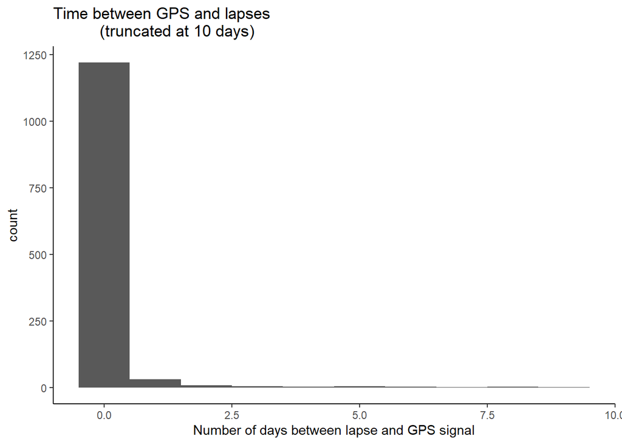

```r
lapses %>%
  filter(tz_distance < 10) %>%
  ggplot(aes(x = tz_distance)) +
  geom_histogram(bins = 10) +
  xlab("Number of days between lapse and GPS signal") +
  ggtitle("Time between GPS and lapses
          (truncated at 10 days)") +
  theme_classic()
```

Most lapses had gps on the same day as the reported lapse. Lets look at those that didn’t.

```r
no_gps <- lapses %>%
  filter(tz_distance > 0)

non_ac <- lapses %>% filter(tz_distance > 0) %>%
  filter(tz != "America/Chicago") %>%
  glimpse()
```

```
## Rows: 4
## Columns: 18
## $ response_id      <chr> "R_3ReF5OEMrlSNePs", "R_2fMO5E6ld3E5Qo9", "R_1ey1d...
## $ subid            <chr> "043", "047", "268", "268"
## $ utc              <dbl> 1520644713, 1524007111, 1572916566, 1572921095
## $ start_date       <dttm> 2018-03-09 19:18:32, 2018-04-17 17:18:30, 2019-11...
## $ end_date         <dttm> 2018-03-09 19:20:50, 2018-04-17 17:19:43, 2019-11...
## $ lapse            <dbl> 2, 2, 2, 2
## $ lapse_start_date <chr> "03-09-2018", "04-17-2018", "11-04-2019", "11-04-2...
## $ lapse_start_hour <dbl> 14, 18, 17, 19
## $ lapse_end_date   <chr> "03-09-2018", "04-17-2018", "11-04-2019", "11-04-2...
## $ lapse_end_hour   <dbl> 20, 19, 18, 19
## $ abstinent        <dbl> 1, 1, 3, 3
## $ finished         <dbl> 1, 1, 1, 1
## $ ema_type         <chr> "later", "later", "later", "later"
## $ tz_date          <date> 2018-03-08, 2018-04-16, 2019-11-03, 2019-11-03
## $ tz_distance      <dbl> 1, 1, 1, 1
## $ tz               <chr> "America/New_York", "America/New_York", "America/D...
## $ start_date_local <chr> "2018-03-09 20:18:32", "2018-04-17 18:18:30", "201...
## $ end_date_local   <chr> "2018-03-09 20:20:50", "2018-04-17 18:19:43", "201...
```

There are **114** lapses across **32** participants that are missing same day gps. Only **4** lapses on days without gps were in a non-Am/Chicago timezone at the time of their lapse, and all of these only had a distance of **1 day.** These were all confirmed to be an accurate guess of their lapse tz in the New tz section of the log. We will examine Am/Chicago no day gps if the participant has multiple timezones in their file:

```r
#Am/Chi lapses without GPS

#Locate subjects who have a lapse without a timezone who traveled to other tzs while on study
no_gps <- lapses %>%
  filter(tz_distance > 0 & tz == "America/Chicago") %>%
  select(subid, response_id) %>%
  pmap_dfr(function(...){
    gps %>%
      filter(subid == ..1) %>%
      rename(tz = lutz_tz) %>%
      filter(!is.na(tz)) %>%
      distinct(tz, .keep_all=TRUE) %>%
      mutate(ntz = nrow(.),
             response_id = ..2) %>%
     select(response_id, ntz)
    }) %>%
  filter(ntz>1) %>%
  semi_join(lapses, ., by="response_id")
```

There are **8** assigned america/chicago lapses (across **5** people who had multiple tzs in their file) that occurred on days with no gps. We will check to make sure we are confident that they were in the am/chicago timezone at these lapse times

```r
#Add cases to log
empty_log <- add_to_log(no_gps, "No day GPS")
```

Review of these lapses confirmed all timezones were correctly assigned (notes in data log). No changes/updates needed to the lapse file for these entries.

### Non-EMA lapses

Non-EMA lapses are lapses reported by participants outside of their EMA reports (usually at follow up sessions). These lapses will not have any affiliate EMA data or response ids, which is why they are added at this stage.

Add non-EMA lapses to the lapse file:

```r
#Pull non-ema lapses from log_add_lapses
#Note: start_date is the date we received the update from the participant for these lapses
non_ema_lapses <- log_add_lapses %>%
  mutate(start_date = mdy(start_date),
         ema_type = "non ema") %>%
  mutate(report_length = start_date - mdy(lapse_start_date),
         start_date_local = as.character(start_date))

#add to lapses file
 lapses <- non_ema_lapses %>%
   select(any_of(names(lapses))) %>%
   bind_rows(lapses, .) %>%
   arrange(subid)
```

### Lapse and Report Lengths

Lapse length is the duration of the reported lapse, calculated as the lapse end time minus the lapse start time.

Report length is the duration of time between when a lapse occurred and when it was reported in the EMA survey. Is is calculated as the EMA survey start time minus the start time of the lapse.

Calcluate length variables:

```r
# Create full date time variables for lapses

lapses <- lapses %>%
  group_by(tz) %>%
  group_map(function(.x, .y, ...){
    .x %>%
      mutate(lapse_start = str_c(mdy(lapse_start_date), " ",
                                 lapse_start_hour,":00:00"),
             lapse_end = str_c(mdy(lapse_end_date), " ",
                               lapse_end_hour, ":00:00")
      ) %>%
      mutate(lapse_start = as_datetime(lapse_start,tz = .y$tz),
             lapse_end = as_datetime(lapse_end, tz = .y$tz),
             report_start = as_datetime(start_date_local, tz = .y$tz)
      ) %>%
      mutate(lapse_length = (lapse_end - lapse_start),
             report_length = (report_start - lapse_start),
  #remove tz variables  before binding
             lapse_start = NULL,
             lapse_end = NULL,
             report_start = NULL)
      }) %>%
  reduce(full_join) %>%
  left_join(lapses, .) %>%
  #Convert lapse and report lengths from seconds to hours
  mutate(lapse_length = as.numeric(lapse_length/3600),
         report_length = as.numeric(report_length/3600))
```

Negative lapse and report lengths:

Negative lengths for these values are impossible (lapses can not end before they start, lapse reports cannot be made before they occur) and will need to be examined by staff

```r
#Negative lapses
nl <- lapses %>%
  filter(lapse_length<0) %>%
  mutate(log_reason = "Neg lapse")
glimpse(nl)
```

```
## Rows: 28
## Columns: 21
## $ response_id      <chr> "R_vH80QgABmvnMxrP", "R_1ez8frIFyiJT8CD", "R_3Dwg9...
## $ subid            <chr> "011", "016", "037", "053", "053", "056", "056", "...
## $ utc              <dbl> 1500711881, 1507446383, 1523763582, 1522811854, 15...
## $ start_date       <dttm> 2017-07-22 02:24:41, 2017-10-08 01:06:23, 2018-04...
## $ end_date         <dttm> 2017-07-22 02:26:06, 2017-10-08 01:08:04, 2018-04...
## $ lapse            <dbl> 2, 2, 2, 2, 2, 2, 2, 2, 2, 2, 2, 2, 2, 2, 2, 2, 2,...
## $ lapse_start_date <chr> "07-22-2017", "10-08-2017", "04-14-2018", "04-04-2...
## $ lapse_start_hour <dbl> 24, 24, 16, 20, 18, 24, 13, 24, 13, 23, 12, 17, 23...
## $ lapse_end_date   <chr> "07-22-2017", "10-08-2017", "04-07-2018", "04-03-2...
## $ lapse_end_hour   <dbl> 1, 1, 19, 23, 16, 23, 1, 3, 2, 2, 12, 11, 24, 1, 2...
## $ abstinent        <dbl> 1, 3, 2, 2, 3, 2, 2, 2, 2, 2, 3, 3, 1, 2, 2, 2, 3,...
## $ finished         <dbl> 1, 1, 1, 1, 1, 1, 1, 0, 1, 1, 1, 1, 1, 1, 1, 1, 0,...
## $ ema_type         <chr> "later", "later", "later", "later", "later", "morn...
## $ tz_date          <date> 2017-07-22, 2017-10-08, 2018-04-14, 2018-04-04, 2...
## $ tz_distance      <dbl> 0, 0, 0, 0, 1, 65, 8, 72, 15, 0, 0, 0, 0, 0, 1, 0,...
## $ tz               <chr> "America/Chicago", "America/Chicago", "America/Chi...
## $ start_date_local <chr> "2017-07-22 02:24:41", "2017-10-08 01:06:23", "201...
## $ end_date_local   <chr> "2017-07-22 02:26:06", "2017-10-08 01:08:04", "201...
## $ lapse_length     <dbl> -23, -23, -165, -21, -2, -1, -12, -21, -11, -165, ...
## $ report_length    <dbl> -21.588611, -22.893611, 5.661667, -22.707222, 2.09...
## $ log_reason       <chr> "Neg lapse", "Neg lapse", "Neg lapse", "Neg lapse"...
```

```r
#Negative report lengths
nr <- lapses %>%
  filter(report_length < 0) %>%
  mutate(lr2 = "Neg report")
glimpse(nr)
```

```
## Rows: 58
## Columns: 21
## $ response_id      <chr> "R_VP5LfR17hDlx5cJ", "R_vH80QgABmvnMxrP", "R_3kaCf...
## $ subid            <chr> "007", "011", "011", "016", "034", "037", "039", "...
## $ utc              <dbl> 1498322134, 1500711881, 1501411323, 1507446383, 15...
## $ start_date       <dttm> 2017-06-24 10:35:34, 2017-07-22 02:24:41, 2017-07...
## $ end_date         <dttm> 2017-06-24 10:36:39, 2017-07-22 02:26:06, 2017-07...
## $ lapse            <dbl> 2, 2, 2, 2, 2, 2, 2, 2, 2, 2, 2, 2, 2, 2, 2, 2, 2,...
## $ lapse_start_date <chr> "06-24-2017", "07-22-2017", "07-30-2017", "10-08-2...
## $ lapse_start_hour <dbl> 24, 24, 24, 24, 1, 17, 20, 16, 21, 21, 21, 24, 21,...
## $ lapse_end_date   <chr> "06-25-2017", "07-22-2017", "07-30-2017", "10-08-2...
## $ lapse_end_hour   <dbl> 1, 1, 24, 1, 2, 23, 21, 16, 23, 21, 1, 24, 23, 23,...
## $ abstinent        <dbl> 3, 1, 1, 3, 3, 2, 3, 2, 2, 2, 3, 2, 3, 2, 3, 2, 1,...
## $ finished         <dbl> 1, 1, 1, 1, 1, 1, 1, 1, 1, 1, 1, 1, 1, 1, 1, 1, 1,...
## $ ema_type         <chr> "morning", "later", "later", "later", "morning", "...
## $ tz_date          <date> 2017-06-24, 2017-07-22, 2017-07-30, 2017-10-08, 2...
## $ tz_distance      <dbl> 0, 0, 0, 0, 0, 0, 0, 0, 0, 0, 0, 0, 0, 0, 0, 65, 6...
## $ tz               <chr> "America/Chicago", "America/Chicago", "America/Chi...
## $ start_date_local <chr> "2017-06-24 10:35:34", "2017-07-22 02:24:41", "201...
## $ end_date_local   <chr> "2017-06-24 10:36:39", "2017-07-22 02:26:06", "201...
## $ lapse_length     <dbl> 1, -23, 0, -23, 1, 6, 1, 0, 2, 0, 4, 0, 2, -21, 1,...
## $ report_length    <dbl> -13.40722222, -21.58861111, -19.29944444, -22.8936...
## $ lr2              <chr> "Neg report", "Neg report", "Neg report", "Neg rep...
```

We have **28** negative lapse lengths across **20** participants. We have **58** negative lapse report lengths across **33** participants.

```r
#Create df for log
bad_lengths <- full_join(nl, nr) %>%
  unite("log_reason", log_reason:lr2, sep = "; ", na.rm = TRUE)
```

Now we look at lapse and report lengths that were unusually long in duration. Long durations are not automatically impossible like negative values, but still warrant checking if the duration is serparation from the typical distribution.

Long lapses:

[output not shown]

On average, people report lapses lasting **3** hours. However, there are a wide range of lengths in the data from **-473** to **510**

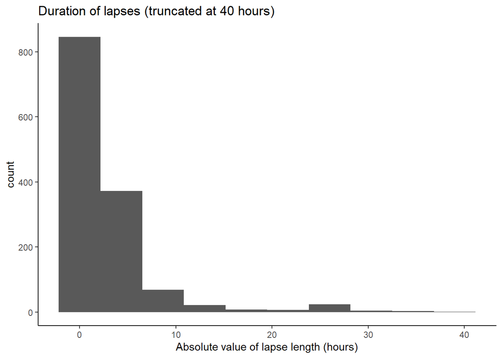

```r
lapses %>%
  filter(abs(lapse_length)< 40) %>%
  ggplot(aes(x = abs(lapse_length))) +
  geom_histogram(bins = 10) +
  xlab("Absolute value of lapse length (hours)") +
  ggtitle("Duration of lapses (truncated at 40 hours)") +
  theme_classic()
```

There is a large drop off in lapse cases around 10 hours. We will examine lapses lasting > 10 hours.

```r
#Get long lapses over 10 hours
ll <- lapses %>%
  filter(abs(lapse_length) > 10) %>%
  mutate(lr2 = "Long lapse")
glimpse(ll)
```

```
## Rows: 84
## Columns: 21
## $ response_id      <chr> NA, "R_3h9jBssRo3T7q1I", "R_vH80QgABmvnMxrP", "R_1...
## $ subid            <chr> "009", "010", "011", "016", "027", "034", "037", "...
## $ utc              <dbl> NA, 1503858196, 1500711881, 1507446383, 1510923972...
## $ start_date       <dttm> 2017-10-04 00:00:00, 2017-08-27 12:23:16, 2017-07...
## $ end_date         <dttm> NA, 2017-08-27 12:24:44, 2017-07-22 02:26:06, 201...
## $ lapse            <dbl> 2, 2, 2, 2, 2, 2, 2, 2, 2, 2, 2, 2, 2, 2, 2, 2, 2,...
## $ lapse_start_date <chr> "09-29-2017", "08-24-2017", "07-22-2017", "10-08-2...
## $ lapse_start_hour <dbl> 0, 18, 24, 24, 20, 21, 12, 22, 22, 15, 16, 24, 0, ...
## $ lapse_end_date   <chr> "09-29-2017", "08-25-2017", "07-22-2017", "10-08-2...
## $ lapse_end_hour   <dbl> 24, 21, 1, 1, 24, 24, 1, 24, 24, 23, 19, 11, 24, 2...
## $ abstinent        <dbl> NA, 3, 1, 3, 3, 3, 2, 2, 2, 2, 2, 2, NA, 1, 2, 2, ...
## $ finished         <dbl> NA, 1, 1, 1, 1, 1, 1, 1, 1, 1, 1, 1, NA, 1, 1, 1, ...
## $ ema_type         <chr> "non ema", "later", "later", "later", "morning", "...
## $ tz_date          <date> NA, 2017-08-24, 2017-07-22, 2017-10-08, 2017-11-1...
## $ tz_distance      <dbl> NA, 0, 0, 0, 0, 0, 0, 0, 0, 0, 0, 2, NA, 0, 0, 0, ...
## $ tz               <chr> "America/Chicago", "America/Chicago", "America/Chi...
## $ start_date_local <chr> "2017-10-04", "2017-08-27 12:23:16", "2017-07-22 0...
## $ end_date_local   <chr> NA, "2017-08-27 12:24:44", "2017-07-22 02:26:06", ...
## $ lapse_length     <dbl> 24, 27, -23, -23, 28, 27, 13, 26, 26, 32, -165, 11...
## $ report_length    <dbl> 120.000000, 66.387778, -21.588611, -22.893611, 11....
## $ lr2              <chr> "Long lapse", "Long lapse", "Long lapse", "Long la...
```

```r
#Add to df for log
bad_lengths <- full_join(bad_lengths, ll) %>%
  unite("log_reason", log_reason:lr2, sep = "; ", na.rm = TRUE)
```

There are **84** lapses across **38** participants that were reported to have lapsed longer than 10 hours.

Long report lengths (the distance between a lapse and the EMA survey it was reported on):

```r
#Identify long report lengths
#Remove non ema lapses for these calculations
ema_rl <- lapses %>%
  filter(!ema_type == "non ema") %>%
  pull(report_length)


describe(c(ema_rl)) %>%
    kable() %>%
  kable_styling(
    bootstrap_options = "condensed",
    full_width = FALSE,
    position = "left")
```

|  | vars | n | mean | sd | median | trimmed | mad | min | max | range | skew | kurtosis | se |
| --- | --- | --- | --- | --- | --- | --- | --- | --- | --- | --- | --- | --- | --- |
| X1 | 1 | 1335 | 16.07334 | 354.6366 | 2.968333 | 4.612934 | 2.9269 | -463.8844 | 12921.45 | 13385.33 | 36.10032 | 1310.619 | 9.70606 |

```r
#for comparison
non_ema_rl <- lapses %>%
  filter(ema_type == "non ema") %>%
  pull(report_length)
```

The average length of time between lapses and their EMA report is **16** hours, but there is a wide window ranging from **-464** to **1.292110^{4}** hours.

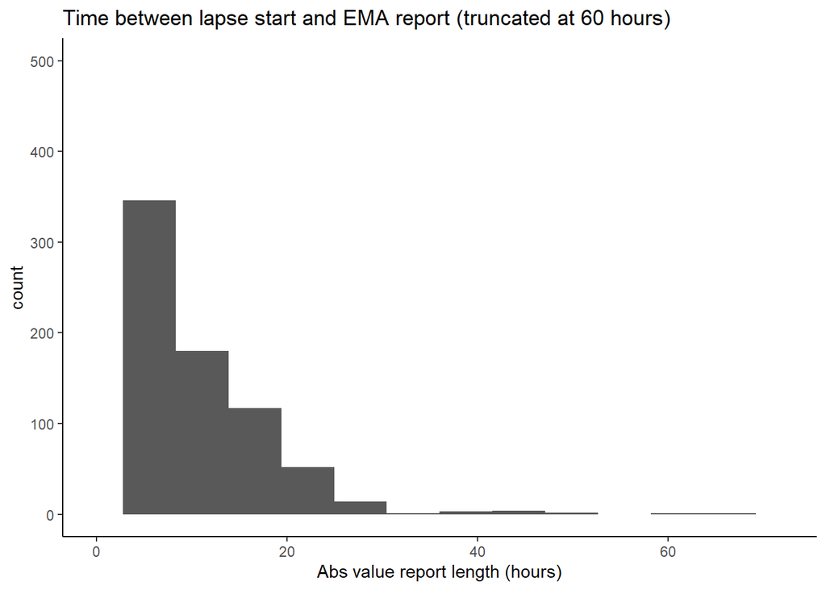

```r
lapses %>%
  filter(!ema_type=="non ema") %>%
  filter(abs(report_length)< 200) %>%
  ggplot(aes(x = abs(report_length))) +
  geom_histogram(bins = 14) +
  xlab("Abs value report length (hours)") +
  ggtitle("Time between lapse start and EMA report (truncated at 60 hours)") +
  xlim(0, 72)+
  ylim(0,500)+
  theme_classic()
```

```r
#Identify long reports > 30 hours

lr <- lapses %>%
  filter(!ema_type=="non ema") %>%
  filter(abs(report_length) > 30) %>%
  mutate(lr2 = "Long report")
```

```r
#Add to bad lengths tibble
bad_lengths <- full_join(bad_lengths, lr) %>%
  unite("log_reason", log_reason:lr2, sep = "; ", na.rm = TRUE)

#Remove all non ema reports (we already examined these)
bad_lengths <- bad_lengths %>%
  filter(!ema_type =="non ema")
```

Overall, we will review **138** lapses across **53** participants due to concerns with the lapse or report length.

```r
#Add to empty log
empty_log <- bad_lengths %>%
  group_by(log_reason) %>%
  group_map(~add_to_log(.x, .y$log_reason)) %>%
    reduce(full_join)

#Additional save with all groups bound together
write_csv(empty_log, file.path(path_out,"log_lapses_empty.csv"))
```

Read in corrections (pending John’s decisions)

```r
lapses <- update_from_log(lapses, "Lapse/report length")

#Now lets check report and lapse lengths after corrections
#recalculating lapse and report lengths
lapses$lapse_length = NULL
lapses$report_length = NULL
lapses <- lapses %>%
  group_by(tz) %>%
  group_map(function(.x, .y, ...){
    .x %>%
      mutate(lapse_start = str_c(mdy(lapse_start_date), " ",
                                 lapse_start_hour,":00:00"),
             lapse_end = str_c(mdy(lapse_end_date), " ",
                               lapse_end_hour, ":00:00")
      ) %>%
      mutate(lapse_start = as_datetime(lapse_start,tz = .y$tz),
             lapse_end = as_datetime(lapse_end, tz = .y$tz),
             report_start = as_datetime(start_date_local, tz = .y$tz)
      ) %>%
      mutate(lapse_length = (lapse_end - lapse_start),
             report_length = (report_start - lapse_start),
              lapse_start_local = as.character(lapse_start),
             lapse_end_local = as.character(lapse_end),
  #remove tz variables  before binding
             lapse_start = NULL,
             lapse_end = NULL,
             report_start = NULL)
      }) %>%
  reduce(full_join) %>%
  left_join(lapses, .) %>%
  #Convert lapse and report lengths from seconds to hours
  mutate(lapse_length = as.numeric(lapse_length/3600),
         report_length = as.numeric(report_length/3600))

#Negative lapse or report lengths?
lapses %>% filter(lapse_length < 0) %>% glimpse()
```

```
## Rows: 0
## Columns: 22
## $ response_id       <chr>
## $ subid             <chr>
## $ utc               <dbl>
## $ start_date        <dttm>
## $ end_date          <dttm>
## $ lapse             <dbl>
## $ lapse_start_date  <chr>
## $ lapse_start_hour  <dbl>
## $ lapse_end_date    <chr>
## $ lapse_end_hour    <dbl>
## $ abstinent         <dbl>
## $ finished          <dbl>
## $ ema_type          <chr>
## $ tz_date           <date>
## $ tz_distance       <dbl>
## $ tz                <chr>
## $ start_date_local  <chr>
## $ end_date_local    <chr>
## $ lapse_length      <dbl>
## $ report_length     <dbl>
## $ lapse_start_local <chr>
## $ lapse_end_local   <chr>
```

```r
lapses %>% filter(report_length<0) %>% View()
#All of these cases were rounded up to the next hour or were before the survey end time, so they are good!
```

Tentative stats for updated lapses:

```r
#long lapses
describe(lapses$lapse_length) %>%
    kable() %>%
  kable_styling(
    bootstrap_options = "condensed",
    full_width = FALSE,
    position = "left")
```

|  | vars | n | mean | sd | median | trimmed | mad | min | max | range | skew | kurtosis | se |
| --- | --- | --- | --- | --- | --- | --- | --- | --- | --- | --- | --- | --- | --- |
| X1 | 1 | 1370 | 3.305109 | 15.33875 | 2 | 2.050183 | 1.4826 | 0 | 510 | 510 | 27.85442 | 882.8263 | 0.4144094 |

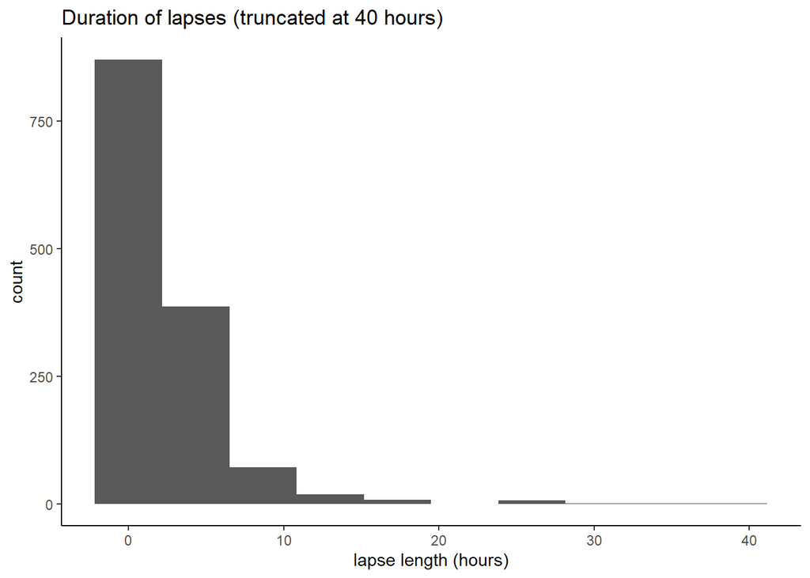

```r
lapses %>%
  filter(lapse_length<40) %>%
  ggplot(aes(x = abs(lapse_length))) +
  geom_histogram(bins = 10) +
  xlab("lapse length (hours)") +
  ggtitle("Duration of lapses (truncated at 40 hours)") +
  theme_classic()
```

```r
#long reports
describe(lapses$report_length) %>%
    kable() %>%
  kable_styling(
    bootstrap_options = "condensed",
    full_width = FALSE,
    position = "left")
```

|  | vars | n | mean | sd | median | trimmed | mad | min | max | range | skew | kurtosis | se |
| --- | --- | --- | --- | --- | --- | --- | --- | --- | --- | --- | --- | --- | --- |
| X1 | 1 | 1370 | 25.84883 | 355.9991 | 3.115556 | 5.213659 | 3.109342 | -2.389167 | 12921.45 | 12923.84 | 34.75433 | 1253.853 | 9.618086 |

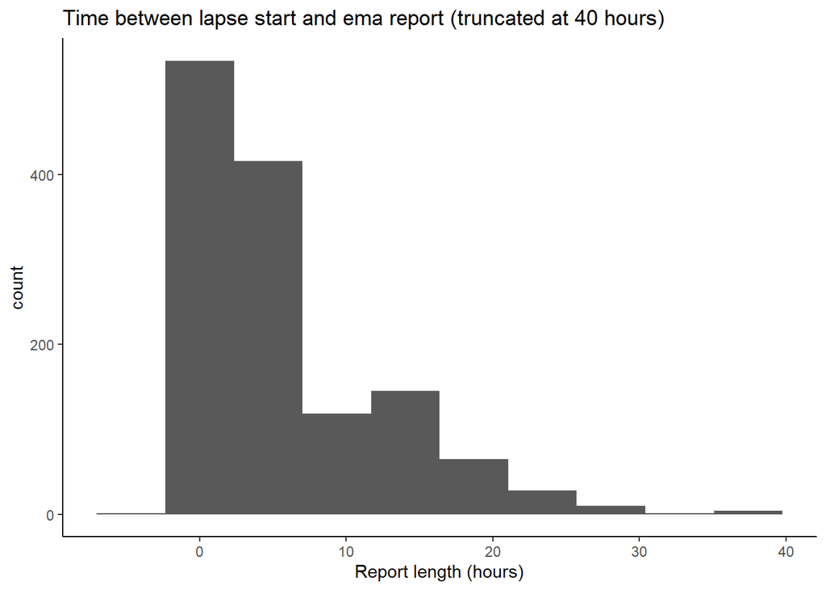

```r
lapses %>%
  filter(report_length<40) %>%
  ggplot(aes(x = report_length)) +
  geom_histogram(bins = 10) +
  xlab("Report length (hours)") +
  ggtitle("Time between lapse start and ema report (truncated at 40 hours)") +
  theme_classic()
```

Distance between lapses In progress Consider combining overlapping/close reports